# Analysis and forecast of Harbor Beach levels

Manuel Hernandez Zemljic

## Introduction

The context of this course work is the analysis of the data-set of the lake levels asked by an environmental agency, and the purpose of this analysis is to provide a forecast for the next 24 months. The data was imported from the text file provided and transformed into a time-series structure. The native R functions acf and pacf provided the autocorrelation functions and partial autocorrelation function used to detect the stationarity or nonstationarity of the data and to obtain an initial set of models to fit.

Importing the data: The data is read from a text file with spaces separator, then as it comes on rows it is needed to transpose and transform in a time series data structure.

```r
w=read.csv("HarborBeach.txt", colClasses = "numeric", sep = " ", header = FALSE)
w=t(w)
w = unlist(w[!is.na(w)], use.names = FALSE)
harbor = ts(w, frequency = 12, start=c(1900,1), end=c(2021,1))
```

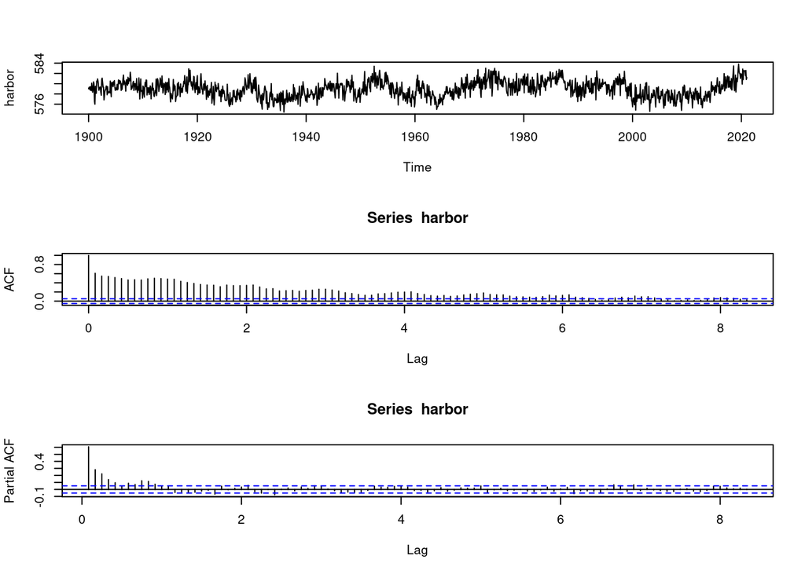

Fig. 1: Harbortime series, acf and pacf.

```r
par(mfrow=c(3,1))
ts.plot(harbor)
acf(harbor,lag.max = 100)
pacf(harbor, lag.max = 100)
```

In figure 1 is appreciated that the acf is decaying very slowly, this pattern of the acf is a sign of nonstationary data. And also on the first graph of the figure I see a sort of trends repeated cyclically. The seasonal component is possible to visualize on the next picture of the average level per month when in June, July and August are the months with the highest lake levels of the year on average, and conversely, January, February, and March are the lowest.

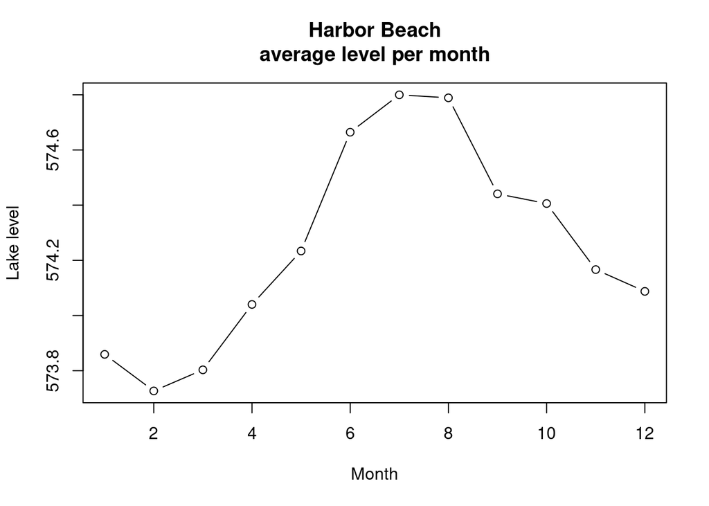

Fig. 2 Harbor Beach average level per month

```r
x = rowMeans(ts_reshape(harbor)[,1:122])
  plot(x, xlab = "Month", ylab = "Lake level",
       main = "Harbor Beach\naverage level per month",
       ylim=c(min(x), max(x)), type="b")
```

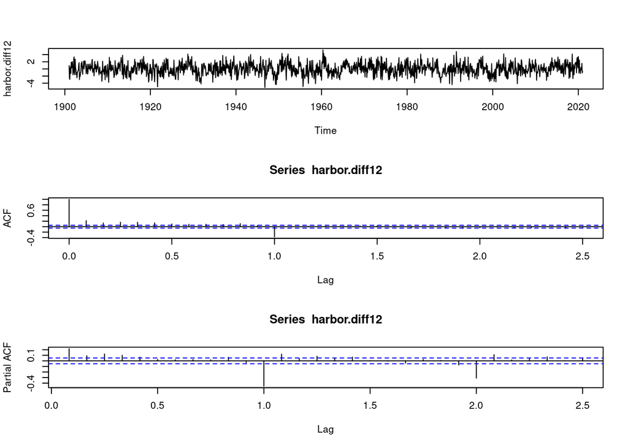

Fig. 3: Time series differenciated at lag 12, acf and pacf

```r
harbor.diff12=diff(harbor,12)
par(mfrow=c(3,1))
plot(harbor.diff12)
acf(harbor.diff12, lag.max=30)
pacf(harbor.diff12, lag.max=30)
```

Looking at the data differenced at lag 12 on this figure, the early lags of the acf make me think there is an AR component in the regular part of the model. An MA component in the seasonal part of the model is suggested by the spike in lag 12. The big spike at lag 1 in the pacf suggests the AR influence. The big spike at lag 12 followed by a small one mean an AR component in the seasonal part of the model as well. As I present on figure 4 I tried here the models ARIMA(1,0,2)x(0,0,1), ARIMA(1,0,2)x(2,0,1), and ARIMA(1,0,2)x(2,0,2). These models have good behavior.

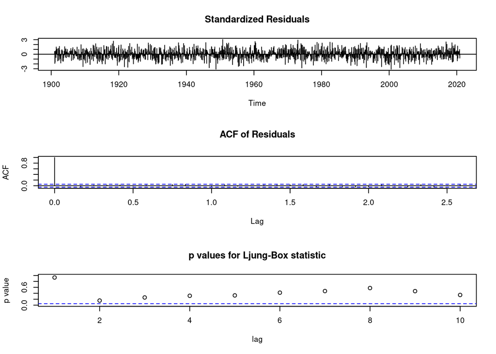

Fig. 4:Fitted model from differenced data at lag 12

```r
fit1 = arima(harbor.diff12, order = c(1,0,2), seasonal = c(0,0,1))
fit2 = arima(harbor.diff12, order = c(1,0,2), seasonal = c(2,0,1))
fit3 = arima(harbor.diff12, order = c(1,0,2), seasonal = c(2,0,2))
tsdiag(fit1)
```

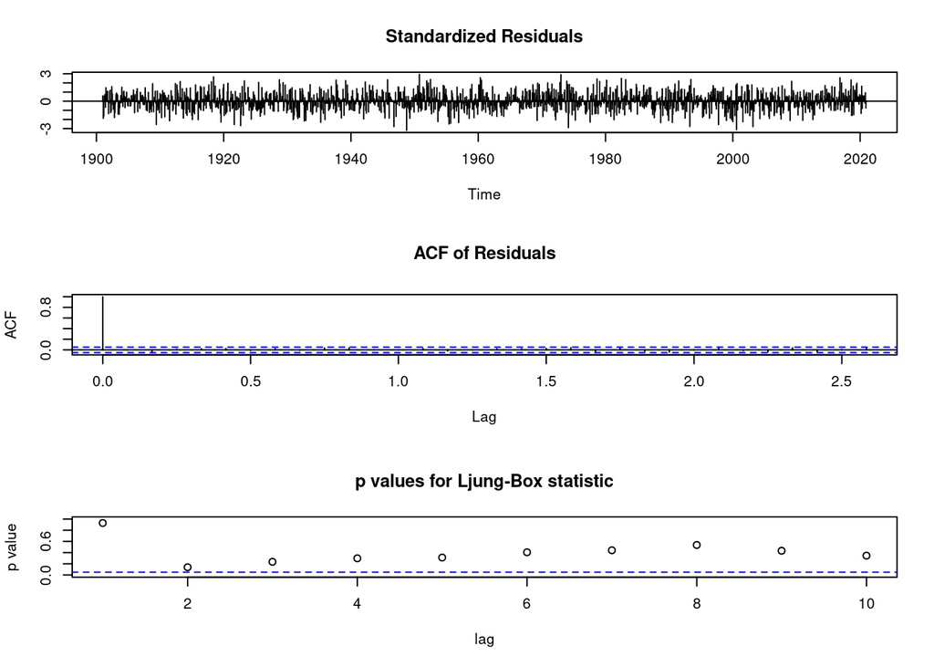

Fig. 4:Fitted model from differenced data at lag 12

```r
tsdiag(fit2)
```

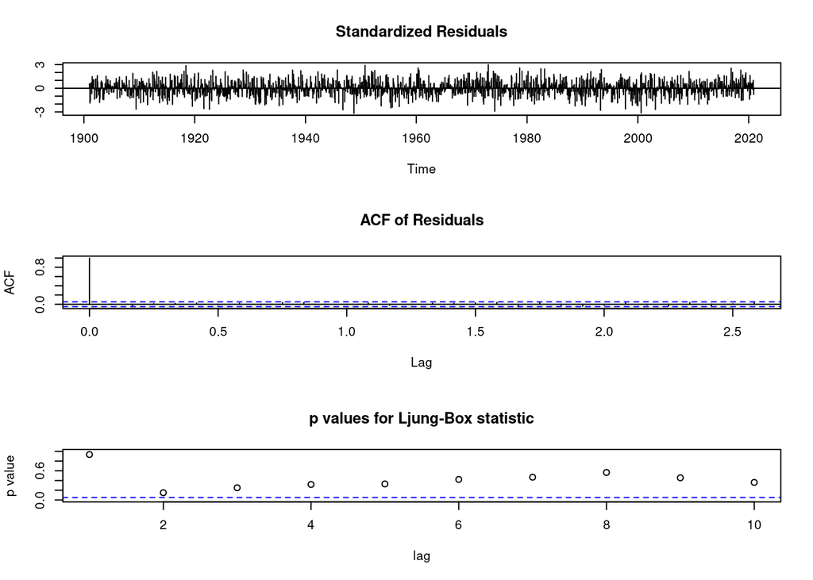

Fig. 4:Fitted model from differenced data at lag 12

```r
tsdiag(fit3)
```

Now I fitted the models with the original data and adjusting de seasonal difference to 1 (D=1) obtaining the models ARIMA(1,0,2)x(0,1,1), ARIMA(1,0,2)x(2,1,1), and ARIMA(1,0,2)x(2,1,2).

In the next figure, I report that for the three models the standardized residuals look like white noize, the acf also behaves like white noise as we have a spike at lag zero which is always present. On the other hand, the p values are higher than 0.05. Even though the p values at lag 2 are quite close to the blue dotted line, it is, like all the other values, above it, hence these models are a good fit.

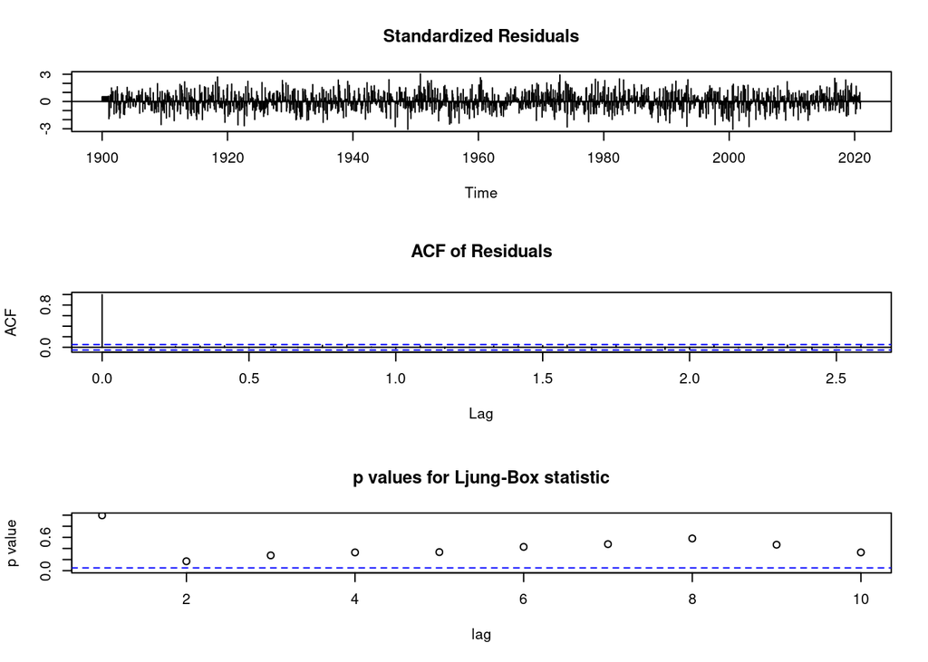

Fig. 5 models fitted

```r
fit.102.011 = arima(harbor, order = c(1,0,2), seasonal = c(0,1,1))
fit.102.211 = arima(harbor, order = c(1,0,2), seasonal = c(2,1,1))
fit.102.212 = arima(harbor, order = c(1,0,2), seasonal = c(2,1,2))
tsdiag(fit.102.011)
```

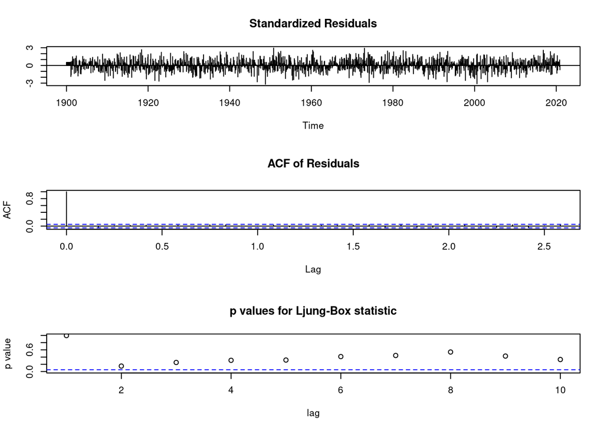

Fig. 5 models fitted

```r
tsdiag(fit.102.211)
```

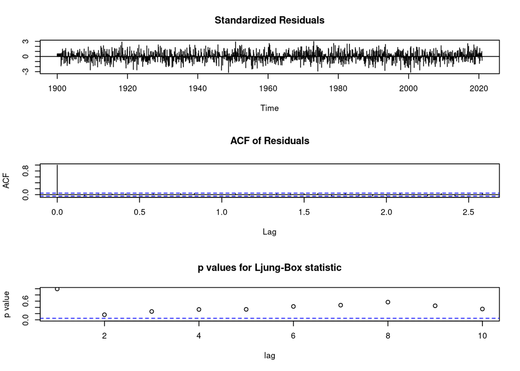

Fig. 5 models fitted

```r
tsdiag(fit.102.212)
```

In this part I test models with first and twelve difference, with that aim I differentiate the data in the variable harbor.diff.diff12 and I proceed to plot the series and its respective acf and pacf. The justification for this approach is that although the data differentiated at lag twelve looks stationary there are short-term trends that I want to filter.

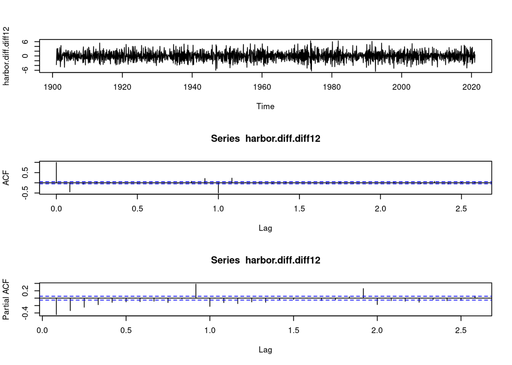

Fig. 6

```r
harbor.diff.diff12=diff(diff(harbor),12)
par(mfrow=c(3,1))
plot(harbor.diff.diff12)
acf(harbor.diff.diff12)
pacf(harbor.diff.diff12)
```

Looking at lag one in the ACF, it has a MA component in the nonseasonal part, but one big spike followed by a small one after lag 12 means it can have also an MA1 or MA2 in the seasonal part of the model. The spike in the pacf at lag 12 is a sign of a cyclical AR component. In the next pictures, I show that the parameter d=1 is worth exploring.

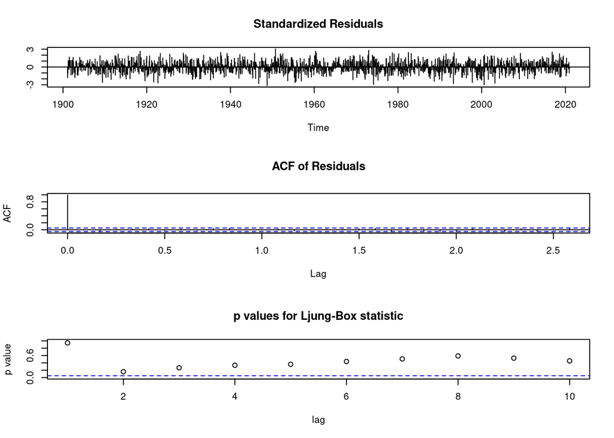

Fig. 7

```r
fit1 = arima(harbor.diff.diff12, order = c(1,0,1), seasonal = c(1,0,1))
fit2 = arima(harbor.diff.diff12, order = c(1,0,2), seasonal = c(0,0,1))
fit3 = arima(harbor.diff.diff12, order = c(1,0,1), seasonal = c(0,0,1))
fit4 = arima(harbor.diff.diff12, order = c(1,0,1), seasonal = c(0,0,2))
fit5 = arima(harbor.diff.diff12, order = c(1,0,1), seasonal = c(1,0,2))
tsdiag(fit1)
```

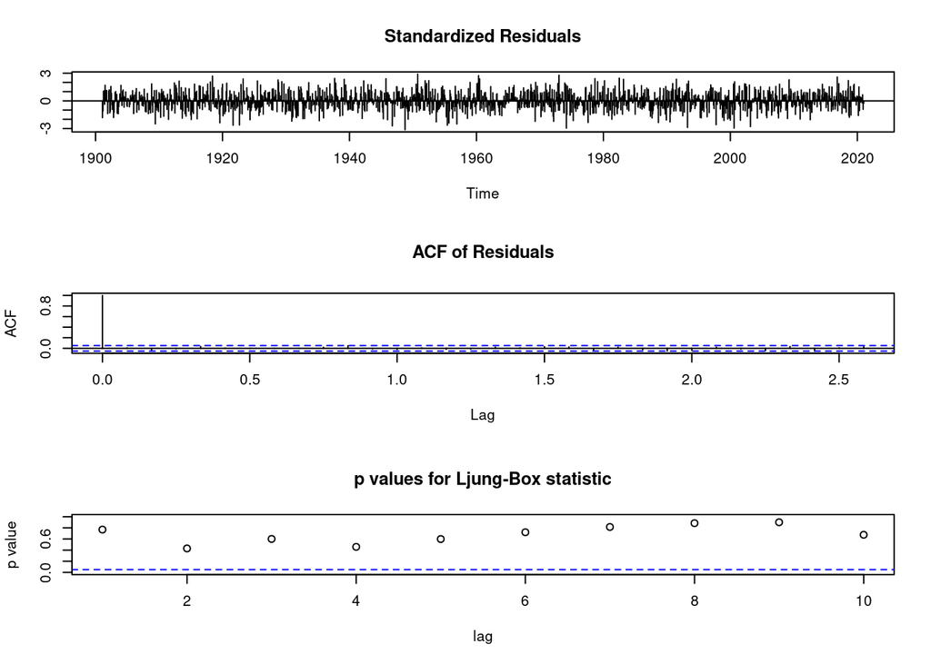

Fig. 7

```r
tsdiag(fit2)
```

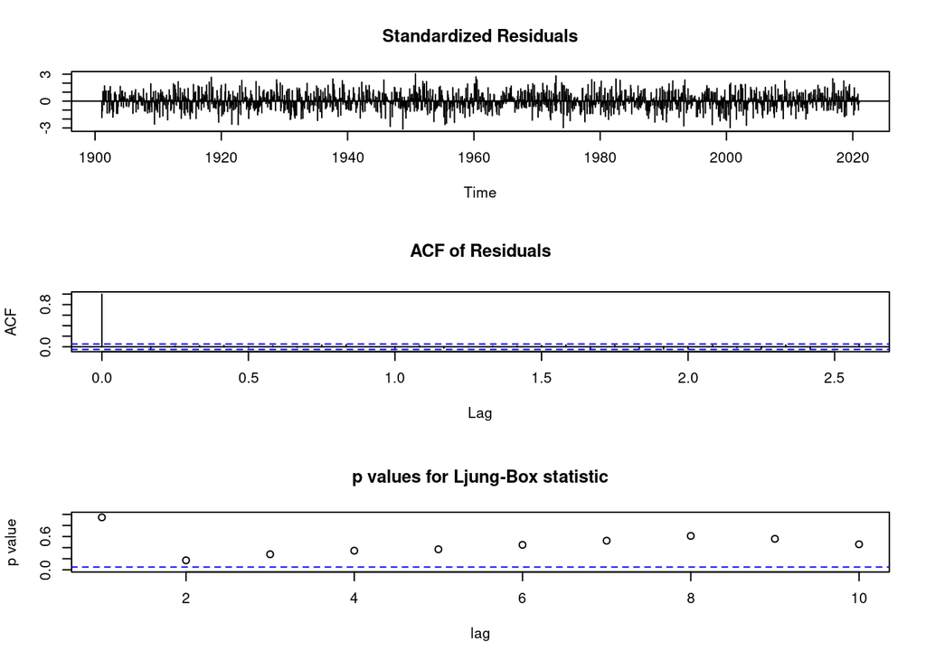

Fig. 7

```r
tsdiag(fit3)
```

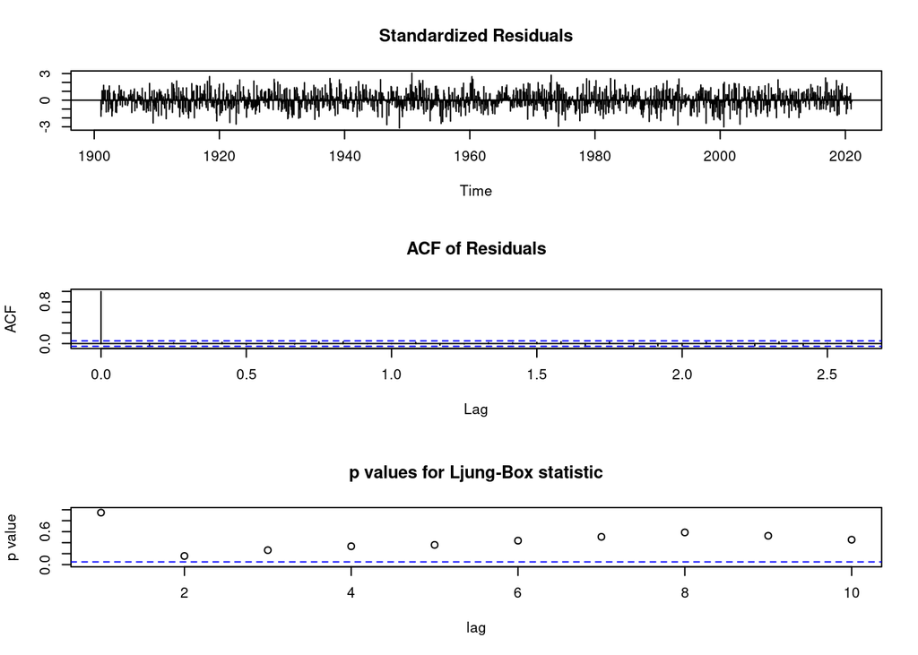

Fig. 7

```r
tsdiag(fit4)
```

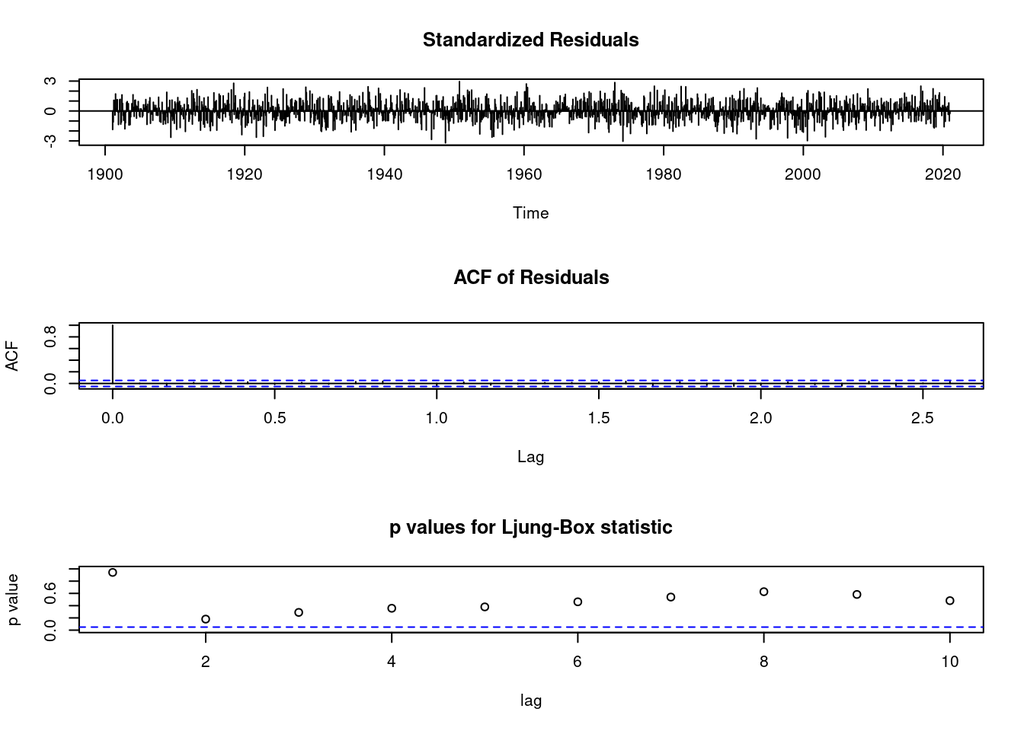

Fig. 7

```r
tsdiag(fit5)
```

```r
fit.111.111 = arima(harbor, order = c(1,1,1), seasonal = c(1,1,1))
fit.112.011 = arima(harbor, order = c(1,1,2), seasonal = c(0,1,1))
fit.111.011 = arima(harbor, order = c(1,1,1), seasonal = c(0,1,1))
fit.111.012 = arima(harbor, order = c(1,1,1), seasonal = c(0,1,2))
fit.111.112 = arima(harbor, order = c(1,1,1), seasonal = c(1,1,2))
```

[output not shown]

In this chunk I store all the models into a list then it is more compact to work with them.

```r
models = list(fit.102.211,
              fit.102.212,
              fit.111.111,
              fit.112.011,
              fit.111.011,
              fit.111.012,
              fit.111.112,
              fit.102.011
)
```

```r
models
```

```
## [[1]]
##
## Call:
## arima(x = harbor, order = c(1, 0, 2), seasonal = c(2, 1, 1))
##
## Coefficients:
##          ar1      ma1      ma2     sar1     sar2     sma1
##       0.9857  -0.7650  -0.0291  -0.0260  -0.0384  -0.9736
## s.e.  0.0056   0.0284   0.0278   0.0274   0.0273   0.0082
##
## sigma^2 estimated as 1.254:  log likelihood = -2225.13,  aic = 4464.26
##
## [[2]]
##
## Call:
## arima(x = harbor, order = c(1, 0, 2), seasonal = c(2, 1, 2))
##
## Coefficients:
##          ar1      ma1      ma2     sar1     sar2     sma1     sma2
##       0.9850  -0.7661  -0.0269  -0.9708  -0.0413  -0.0244  -0.9273
## s.e.  0.0057   0.0284   0.0278   0.0497   0.0282   0.0430   0.0424
##
## sigma^2 estimated as 1.251:  log likelihood = -2223.61,  aic = 4463.22
##
## [[3]]
##
## Call:
## arima(x = harbor, order = c(1, 1, 1), seasonal = c(1, 1, 1))
##
## Coefficients:
##          ar1      ma1     sar1     sma1
##       0.0368  -0.8123  -0.0272  -0.9758
## s.e.  0.0321   0.0179   0.0271   0.0080
##
## sigma^2 estimated as 1.265:  log likelihood = -2231.4,  aic = 4472.8
##
## [[4]]
##
## Call:
## arima(x = harbor, order = c(1, 1, 2), seasonal = c(0, 1, 1))
```

[output cut: 40 more lines]

```
## s.e.  0.0321   0.0180   0.0404   0.0352   0.0340
##
## sigma^2 estimated as 1.262:  log likelihood = -2230.16,  aic = 4472.33
##
## [[8]]
##
## Call:
## arima(x = harbor, order = c(1, 0, 2), seasonal = c(0, 1, 1))
##
## Coefficients:
##          ar1      ma1      ma2     sma1
##       0.9843  -0.7639  -0.0297  -0.9772
## s.e.  0.0059   0.0284   0.0278   0.0079
##
## sigma^2 estimated as 1.256:  log likelihood = -2226.45,  aic = 4462.9
```

And finally, I show in the next output the relation $\frac{coefficient}{s.e.}$, and because R does not include this in the report I made my own function for that purpose. Although the model ARIMA(1,0,2)x(0,1,1)_12 doesn’t have a really good value in this figure, I closed it because I expect this model will have better forecast capacity and less over-fitting based on it has the lowest aic. The ARIMA(1,0,2)(0,1,1)_12 model has AR parameter $\phi_1=0.9843$ MA parameters $\theta_1=0.7639$ and $\theta_2=0.0297$, and SMA parameter $\Theta_1=0.9772$. So the models is
$$(1 - \phi_1 B)(1-B^{12})X_t = (1 - \theta_1 B - \theta_2 B^2)(1 - \Theta_1 B^{12}) Z_t$$
$$(1 - 0.9843 B)(1-B^{12})X_t = (1 - 0.7639 B - 0.0297 B^2)(1 - 0.9772 B^{12}) Z_t$$

```r
modelSummary = function(models){
  for (i in 1:length(models)){
    x=paste("ARIMA (",paste(models[[i]]$call$order[2:4], collapse = ","),")",
          "(",paste(models[[i]]$call$seasonal[2:4], collapse = ","),")", collapse = "")
    w=as.data.frame(models[[i]]$coef/sqrt(diag(models[[i]]$var.coef)))
    w=t(w)
    rownames(w)=NULL
    #print(data.frame(model=x, aic=model$aic, w))
    print(x)
    print(models[[i]]$aic)
    print(w)
  }
}
modelSummary(models)
```

```
## [1] "ARIMA ( 1,0,2 ) ( 2,1,1 )"
## [1] 4464.258
##           ar1       ma1       ma2       sar1      sar2     sma1
## [1,] 175.0759 -26.96357 -1.048513 -0.9480306 -1.404347 -118.538
## [1] "ARIMA ( 1,0,2 ) ( 2,1,2 )"
## [1] 4463.218
##           ar1       ma1        ma2      sar1      sar2       sma1      sma2
## [1,] 171.4104 -26.99556 -0.9661186 -19.52447 -1.463471 -0.5680118 -21.87905
## [1] "ARIMA ( 1,1,1 ) ( 1,1,1 )"
## [1] 4472.804
##           ar1      ma1      sar1      sma1
## [1,] 1.147666 -45.3394 -1.002695 -122.6364
## [1] "ARIMA ( 1,1,2 ) ( 0,1,1 )"
## [1] 4467.374
##            ar1      ma1       ma2      sma1
```

[output cut: 17 more lines]

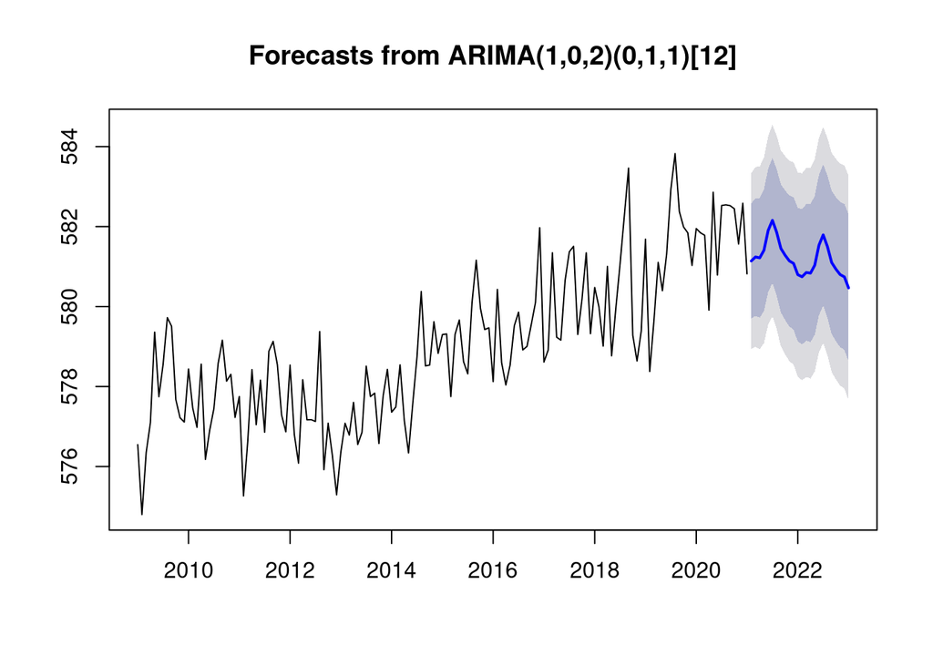

Fig. 9: Forecast plot with 10% of the data (easier to visualice)

```r
forecast(fit.102.011)%>%  plot(include=(1453*.1))
```

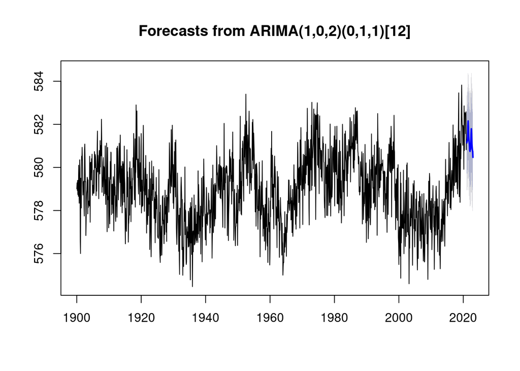

Fig. 10: Forecast plot with 100% of the data

```r
forecast(fit.102.011)%>%  plot()
```

To finalize I include the forecast for the next two years as in the next table:

```r
forecast(fit.102.011)
```

```
##          Point Forecast    Lo 80    Hi 80    Lo 95    Hi 95
## Feb 2021       581.1401 579.7039 582.5763 578.9436 583.3365
## Mar 2021       581.2408 579.7701 582.7114 578.9916 583.4899
## Apr 2021       581.2184 579.7234 582.7134 578.9320 583.5048
## May 2021       581.4085 579.8903 582.9267 579.0866 583.7304
## Jun 2021       581.9057 580.3653 583.4461 579.5499 584.2616
## Jul 2021       582.1570 580.5954 583.7186 579.7688 584.5452
## Aug 2021       581.8582 580.2764 583.4400 579.4390 584.2773
## Sep 2021       581.4538 579.8526 583.0550 579.0050 583.9026
## Oct 2021       581.2838 579.6641 582.9035 578.8066 583.7609
## Nov 2021       581.1422 579.5047 582.7796 578.6379 583.6465
## Dec 2021       581.0787 579.4242 582.7332 578.5484 583.6090
## Jan 2022       580.7977 579.1269 582.4685 578.2424 583.3529
## Feb 2022       580.7453 579.0540 582.4365 578.1587 583.3318
## Mar 2022       580.8530 579.1458 582.5603 578.2421 583.4640
## Apr 2022       580.8368 579.1144 582.5592 578.2026 583.4710
## May 2022       581.0329 579.2959 582.7699 578.3763 583.6894
## Jun 2022       581.5360 579.7850 583.2871 578.8580 584.2140
## Jul 2022       581.7931 580.0286 583.5576 579.0945 584.4917
## Aug 2022       581.5000 579.7225 583.2775 578.7816 584.2184
## Sep 2022       581.1013 579.3113 582.8912 578.3638 583.8388
## Oct 2022       580.9368 579.1348 582.7387 578.1809 583.6926
## Nov 2022       580.8007 578.9872 582.6142 578.0272 583.5742
## Dec 2022       580.7425 578.9179 582.5672 577.9520 583.5330
## Jan 2023       580.4668 578.6315 582.3021 577.6600 583.2737
```

## Conclusions

The model ARIMA(1,0,2)(0,1,1)_12 has been selected as the best fit for the forecast of the future 24 months levels of the lake. The auto-correlation and partial auto-correlation values were plotted for different lags. The study of these plots revealed that the data had signs of being nonstationary and that is why it was necessary to differentiate it at lag 12, converting the data into stationary. These plots were used to obtain a set of models that passed the Ljung-Box statistic, and after that, the model with the lowest Akaike Information Criterion was chosen. A table with the foretasted points and confidence intervals at 80 and 95 percent were presented.